# ECON432 HW5 R Exercises

YUANJIAN ZHOU

Mar 10,2020

# 1

```r
library(PerformanceAnalytics)
library(fGarch)
library(tseries)
library(car)
library(quantmod)
```

## preparation

```r
get_price = function(tick) {
  result = suppressWarnings(
    get.hist.quote(
      instrument = tick,
      quote = "AdjClose",
      provider = "yahoo",
      start = "2000-01-03",
      end = "2014-02-21",
      compression = "m",
      retclass = "zoo"
    )
  )
  return(result)
}
GSPC = get_price("^GSPC")
```

[output not shown]

```
## time series starts 2000-01-01
## time series ends   2014-02-01
```

```r
MSFT = get_price("MSFT")
```

```
## time series starts 2000-01-01
## time series ends   2014-02-01
```

```r
data_price = merge.zoo(GSPC, MSFT) # merge zoo objects with same index
colnames(data_price) = c("GSPC", "MSFT")
# change index to Month-Year format, like Mar 1995
index(data_price) = as.yearmon(index(data_price), "%B%y")
# rt = lnpt - lnpt-1
data_ccreturn = diff(log(data_price))
```

# (a)

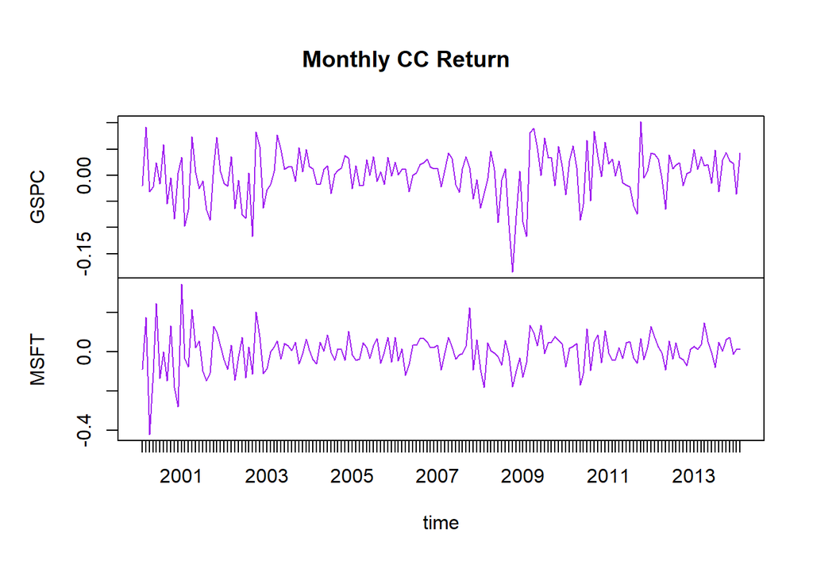

```r
plot(data_ccreturn,
     main = "Monthly CC Return",
     xlab = "time",
     col = "purple")
```

- We can see that there is weak (or even no) time dependence, volatility clustering, and it seems both series have a lot of outliers. What’more, the series look like random walk.

## (b)

```r
fourplots = function(tick) {
  par(mfrow = c(2, 2))
  data = data_ccreturn[, tick]
  # return plot
  plot(data,
     main = "Monthly CC Return",
     xlab = "time",
     col = "purple")

  # acf
  acf(data)

  # density plot
  plot(
    density(data),
    type = "l",
    main = "Denstiy Plot",
    xlab = "monthly cc return",
    ylab = "probability",
    col = "purple"
  )

  # qqplot
  qqPlot( ~ data,
          col = "purple",
          ylab = "sample quantitles",
          main = "QQ plot")
}
```

- *MSFT*

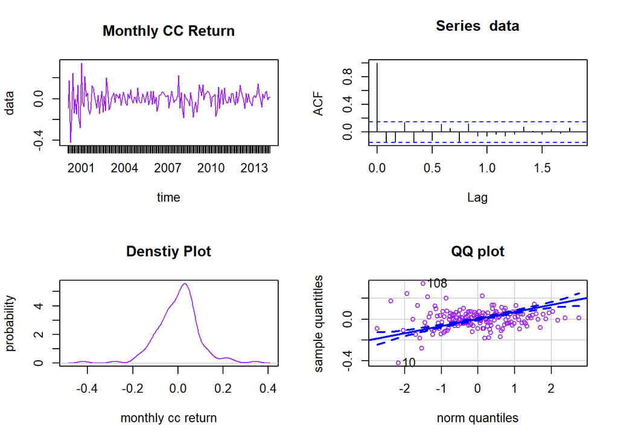

```
## [1]  10 108
```

```r
fourplots("MSFT")
```

- *GSPC*

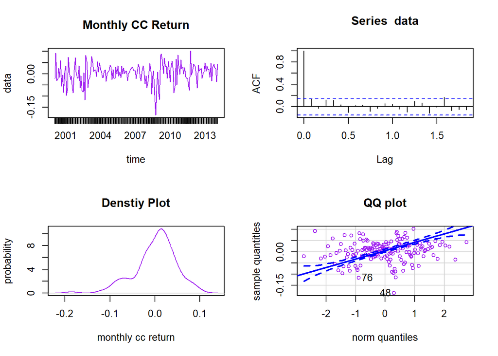

```
## [1] 48 76
```

```r
fourplots("GSPC")
```

- Both return eries do not look normally distributed.

## (c)

```r
jarque.bera.test(data_ccreturn$GSPC)
```

```
##
##  Jarque Bera Test
##
## data:  data_ccreturn$GSPC
## X-squared = 26.121, df = 2, p-value = 2.128e-06
```

```r
jarque.bera.test(data_ccreturn$MSFT)
```

```
##
##  Jarque Bera Test
##
## data:  data_ccreturn$MSFT
## X-squared = 77.167, df = 2, p-value < 2.2e-16
```

- From the results, Jarque Bera Test refuses H0 that X is normally distributed for both series, that means they are not normally distributed.

## (d)

- *MSFT*

```r
garch_MSFT = garchFit(~garch(1,1), data = data_ccreturn$MSFT, trace = F)
summary(garch_MSFT)
```

```
##
## Title:
##  GARCH Modelling
##
## Call:
##  garchFit(formula = ~garch(1, 1), data = data_ccreturn$MSFT, trace = F)
##
## Mean and Variance Equation:
##  data ~ garch(1, 1)
## <environment: 0x000000001abf78c8>
##  [data = data_ccreturn$MSFT]
##
## Conditional Distribution:
##  norm
##
## Coefficient(s):
##         mu       omega      alpha1       beta1
## 0.00363038  0.00058154  0.13319980  0.77385872
##
## Std. Errors:
##  based on Hessian
##
## Error Analysis:
##         Estimate  Std. Error  t value Pr(>|t|)
## mu     0.0036304   0.0055352    0.656    0.512
## omega  0.0005815   0.0005669    1.026    0.305
## alpha1 0.1331998   0.0948080    1.405    0.160
## beta1  0.7738587   0.1579608    4.899 9.63e-07 ***
## ---
## Signif. codes:  0 '***' 0.001 '**' 0.01 '*' 0.05 '.' 0.1 ' ' 1
##
## Log Likelihood:
##  184.5674    normalized:  1.092115
##
## Description:
##  Tue Mar 10 21:32:40 2020 by user:
##
##
## Standardised Residuals Tests:
##                                 Statistic p-Value
##  Jarque-Bera Test   R    Chi^2  21.84865  1.801466e-05
##  Shapiro-Wilk Test  R    W      0.9796452 0.01387566
##  Ljung-Box Test     R    Q(10)  9.558408  0.4800507
##  Ljung-Box Test     R    Q(15)  11.63327  0.7065486
##  Ljung-Box Test     R    Q(20)  13.19663  0.8687889
##  Ljung-Box Test     R^2  Q(10)  4.60893   0.9157265
##  Ljung-Box Test     R^2  Q(15)  8.162799  0.91709
##  Ljung-Box Test     R^2  Q(20)  10.11454  0.9660472
##  LM Arch Test       R    TR^2   11.4691   0.4892008
##
## Information Criterion Statistics:
##       AIC       BIC       SIC      HQIC
## -2.136893 -2.062812 -2.137979 -2.106829
```

- $\alpha + \beta = 0.13 + 0.77 = 0.9$
- *GSPC*

```r
garch_GSPC = garchFit(~garch(1,1), data = data_ccreturn$GSPC, trace = F)
summary(garch_GSPC)
```

```
##
## Title:
##  GARCH Modelling
##
## Call:
##  garchFit(formula = ~garch(1, 1), data = data_ccreturn$GSPC, trace = F)
##
## Mean and Variance Equation:
##  data ~ garch(1, 1)
## <environment: 0x0000000024052c58>
##  [data = data_ccreturn$GSPC]
##
## Conditional Distribution:
##  norm
##
## Coefficient(s):
##         mu       omega      alpha1       beta1
## 6.3411e-03  6.1623e-05  2.3077e-01  7.5490e-01
##
## Std. Errors:
##  based on Hessian
##
## Error Analysis:
##         Estimate  Std. Error  t value Pr(>|t|)
## mu     6.341e-03   2.518e-03    2.518  0.01179 *
## omega  6.162e-05   5.470e-05    1.127  0.25988
## alpha1 2.308e-01   7.527e-02    3.066  0.00217 **
## beta1  7.549e-01   7.014e-02   10.762  < 2e-16 ***
## ---
## Signif. codes:  0 '***' 0.001 '**' 0.01 '*' 0.05 '.' 0.1 ' ' 1
##
## Log Likelihood:
##  300.7408    normalized:  1.779531
##
## Description:
##  Tue Mar 10 21:32:40 2020 by user:
##
##
## Standardised Residuals Tests:
##                                 Statistic p-Value
##  Jarque-Bera Test   R    Chi^2  8.113598  0.01730432
##  Shapiro-Wilk Test  R    W      0.9747858 0.003581677
##  Ljung-Box Test     R    Q(10)  3.963462  0.9489802
##  Ljung-Box Test     R    Q(15)  5.783511  0.9831592
##  Ljung-Box Test     R    Q(20)  17.35204  0.6300102
##  Ljung-Box Test     R^2  Q(10)  4.916875  0.8966612
##  Ljung-Box Test     R^2  Q(15)  6.492295  0.9702403
##  Ljung-Box Test     R^2  Q(20)  10.58991  0.9561723
##  LM Arch Test       R    TR^2   8.365917  0.7559215
##
## Information Criterion Statistics:
##       AIC       BIC       SIC      HQIC
## -3.511726 -3.437645 -3.512812 -3.481662
```

- $\alpha + \beta = 0.23 + 0.75 = 0.98$
- Both series have a $\alpha + \beta \geq 0.9$, which means that both series has a very high persistence, the volatility clustering is very strong.

## (e)

- Using the summary table above:
- *GSPC*

```r
# for alpha
alpha_ci_95_l =  0.2308 - 1.96 * 7.527e-02
alpha_ci_95_u =  0.2308 + 1.96 * 7.527e-02
sprintf("95 percent confidence interval for alpha is [%f,%f]", alpha_ci_95_l, alpha_ci_95_u)
```

```
## [1] "95 percent confidence interval for alpha is [0.083271,0.378329]"
```

```r
# for beta
beta_ci_95_l = 0.7549 - 1.96 * 7.014e-02
beta_ci_95_u = 0.7549 + 1.96 * 7.014e-02
sprintf("95 percent confidence interval for beta is [%f,%f]", beta_ci_95_l, beta_ci_95_u)
```

```
## [1] "95 percent confidence interval for beta is [0.617426,0.892374]"
```

- *MSFT*

```r
# for alpha
alpha_ci_95_l =  0.1332 - 1.96 * 0.0948
alpha_ci_95_u =  0.1332 + 1.96 * 0.0948
sprintf("95 percent confidence interval for alpha is [%f,%f]", alpha_ci_95_l, alpha_ci_95_u)
```

```
## [1] "95 percent confidence interval for alpha is [-0.052608,0.319008]"
```

```r
# for beta
beta_ci_95_l = 0.774 - 1.96 * 0.158
beta_ci_95_u = 0.774 + 1.96 * 0.158
sprintf("95 percent confidence interval for beta is [%f,%f]", beta_ci_95_l, beta_ci_95_u)
```

```
## [1] "95 percent confidence interval for beta is [0.464320,1.083680]"
```

## (f)

- Using the summary table above:
- *GSPC*
  $$\begin{align*}
  H_0&: \alpha_1 = 0\\
  t &= \frac{0.2308-0}{0.07527} \approx 3.066>1.96 = t_{0.975}
  \end{align*}$$
- So we reject $H_0:\alpha_1 = 0$ with 95 % confidence.

$$\begin{align*}
H_0&: \beta_1 = 0.9\\
t &= \frac{0.7594-0.9}{0.07014} \approx -2<-1.96 = t_{0.025}
\end{align*}$$

- So we reject $H_0:\beta_1 = 0.9$ with 95 % confidence.
- *MSFT*
  $$\begin{align*}
  H_0&: \alpha_1 = 0\\
  t &= \frac{0.1332-0}{0.0948} \approx 1.41<1.96 = t_{0.975}
  \end{align*}$$
- So we can not reject $H_0:\alpha_1 = 0$ with 95 % confidence.

$$\begin{align*}
H_0&: \beta_1 = 0.9\\
t &= \frac{0.774-0.9}{0.158} \approx -0.8>-1.96 = t_{0.025}
\end{align*}$$

- So we can not reject $H_0:\beta_1 = 0.9$ with 95 % confidence.